# Tarea11_AlejandroBarrantes

Alejandro Barrantes Castro

2023-05-31

```r
setwd("~/ALEJANDRO/1er Ciclo 2023/Mineria de Datos/Tarea 7/Datos Clase y Tareas")
Datos <- read.csv("Tumores.csv", header=TRUE, sep=',',dec='.',stringsAsFactors = T)
enteros <- sapply(Datos, is.integer)
Datos[enteros] <- lapply(Datos[enteros], as.factor)

Datos$tipo <- factor(Datos$tipo)
Datos <- subset(Datos, select = -1)

set.seed(123) # Fijamos la semilla para reproducibilidad
indice <- createDataPartition(y = Datos$tipo, p = 0.25, list = FALSE)
ttesting <- Datos[indice, ]
ttraining <- Datos[-indice, ]
str(Datos)
```

```
## 'data.frame':    1275 obs. of  17 variables:
##  $ media              : num  23.45 4.4 3.24 8.51 21 ...
##  $ varianza           : num  2539 835 642 1126 2235 ...
##  $ desviacion.estandar: num  50.4 28.9 25.3 33.6 47.3 ...
##  $ entropia           : num  0.651 0.954 0.966 0.869 0.685 ...
##  $ asimetria          : num  1.98 6.5 7.77 3.76 1.94 ...
##  $ kurtosis           : num  5.42 43.35 61.76 15.11 4.72 ...
##  $ contraste          : num  181.5 76.7 81.8 362.3 312.4 ...
##  $ energia            : num  0.782 0.973 0.98 0.922 0.804 ...
##  $ asm                : num  0.611 0.946 0.961 0.85 0.647 ...
##  $ homogeneidad       : num  0.847 0.981 0.985 0.949 0.88 ...
##  $ disiminitud        : num  2.765 0.549 0.54 2.766 3.007 ...
##  $ correlacion        : num  0.969 0.96 0.944 0.859 0.939 ...
##  $ psnr               : num  98 110.3 112.3 102 97.6 ...
##  $ ssim               : num  0.777 0.978 0.985 0.881 0.766 ...
##  $ mse                : num  0.17116 0.00991 0.00637 0.06844 0.18488 ...
##  $ dc                 : num  0.304 0.839 0.85 0 0 ...
##  $ tipo               : Factor w/ 2 levels "0","1": 2 2 2 1 1 1 2 2 2 2 ...
```

# EJERCICIO 1

## 1.1

```r
str(Datos)
```

```
## 'data.frame':    1275 obs. of  17 variables:
##  $ media              : num  23.45 4.4 3.24 8.51 21 ...
##  $ varianza           : num  2539 835 642 1126 2235 ...
##  $ desviacion.estandar: num  50.4 28.9 25.3 33.6 47.3 ...
##  $ entropia           : num  0.651 0.954 0.966 0.869 0.685 ...
##  $ asimetria          : num  1.98 6.5 7.77 3.76 1.94 ...
##  $ kurtosis           : num  5.42 43.35 61.76 15.11 4.72 ...
##  $ contraste          : num  181.5 76.7 81.8 362.3 312.4 ...
##  $ energia            : num  0.782 0.973 0.98 0.922 0.804 ...
##  $ asm                : num  0.611 0.946 0.961 0.85 0.647 ...
##  $ homogeneidad       : num  0.847 0.981 0.985 0.949 0.88 ...
##  $ disiminitud        : num  2.765 0.549 0.54 2.766 3.007 ...
##  $ correlacion        : num  0.969 0.96 0.944 0.859 0.939 ...
##  $ psnr               : num  98 110.3 112.3 102 97.6 ...
##  $ ssim               : num  0.777 0.978 0.985 0.881 0.766 ...
##  $ mse                : num  0.17116 0.00991 0.00637 0.06844 0.18488 ...
##  $ dc                 : num  0.304 0.839 0.85 0 0 ...
##  $ tipo               : Factor w/ 2 levels "0","1": 2 2 2 1 1 1 2 2 2 2 ...
```

```r
summary(Datos)
```

```
##      media              varianza        desviacion.estandar    entropia
##  Min.   : 0.001541   Min.   :   0.156   Min.   : 0.3945     Min.   :0.5307
##  1st Qu.: 0.381950   1st Qu.:  58.557   1st Qu.: 7.6523     1st Qu.:0.9326
##  Median : 1.826401   Median : 280.429   Median :16.7460     Median :0.9757
##  Mean   : 4.029659   Mean   : 486.384   Mean   :18.3179     Mean   :0.9344
##  3rd Qu.: 4.974586   3rd Qu.: 707.677   3rd Qu.:26.6022     3rd Qu.:0.9943
##  Max.   :31.031021   Max.   :3345.854   Max.   :57.8434     Max.   :0.9999
##    asimetria          kurtosis          contraste           energia
##  Min.   :  1.219   Min.   :    2.50   Min.   :  0.3557   Min.   :0.6959
##  1st Qu.:  5.437   1st Qu.:   30.57   1st Qu.: 20.7866   1st Qu.:0.9603
##  Median :  9.377   Median :   88.95   Median : 50.4217   Median :0.9858
##  Mean   : 16.996   Mean   :  742.22   Mean   : 75.0515   Mean   :0.9600
##  3rd Qu.: 20.320   3rd Qu.:  415.83   3rd Qu.: 97.1238   3rd Qu.:0.9967
##  Max.   :255.995   Max.   :65534.24   Max.   :743.3681   Max.   :1.0000
##       asm          homogeneidad     disiminitud        correlacion
##  Min.   :0.4843   Min.   :0.8111   Min.   :0.003522   Min.   :-0.0000349
##  1st Qu.:0.9223   1st Qu.:0.9730   1st Qu.:0.150540   1st Qu.: 0.8308350
##  Median :0.9718   Median :0.9895   Median :0.415167   Median : 0.9001476
##  Mean   :0.9257   Mean   :0.9739   Mean   :0.704138   Mean   : 0.8650773
##  3rd Qu.:0.9934   3rd Qu.:0.9975   3rd Qu.:0.821914   3rd Qu.: 0.9419782
##  Max.   :0.9999   Max.   :1.0000   Max.   :5.604428   Max.   : 0.9901755
##       psnr             ssim             mse                  dc
##  Min.   : 53.38   Min.   :0.6760   Min.   :0.0002257   Min.   :0.00000
##  1st Qu.: 62.04   1st Qu.:0.9369   1st Qu.:0.0118142   1st Qu.:0.08947
##  Median : 64.94   Median :0.9612   Median :0.0235417   Median :0.36098
##  Mean   : 68.90   Mean   :0.9395   Mean   :0.0424071   Mean   :0.38858
##  3rd Qu.: 68.75   3rd Qu.:0.9773   3rd Qu.:0.0440017   3rd Qu.:0.65969
##  Max.   :123.29   Max.   :0.9993   Max.   :0.2986979   Max.   :0.95797
##  tipo
##  0:  97
##  1:1178
##
##
##
##
```

```r
dim(Datos)
```

```
## [1] 1275   17
```

## 1.2

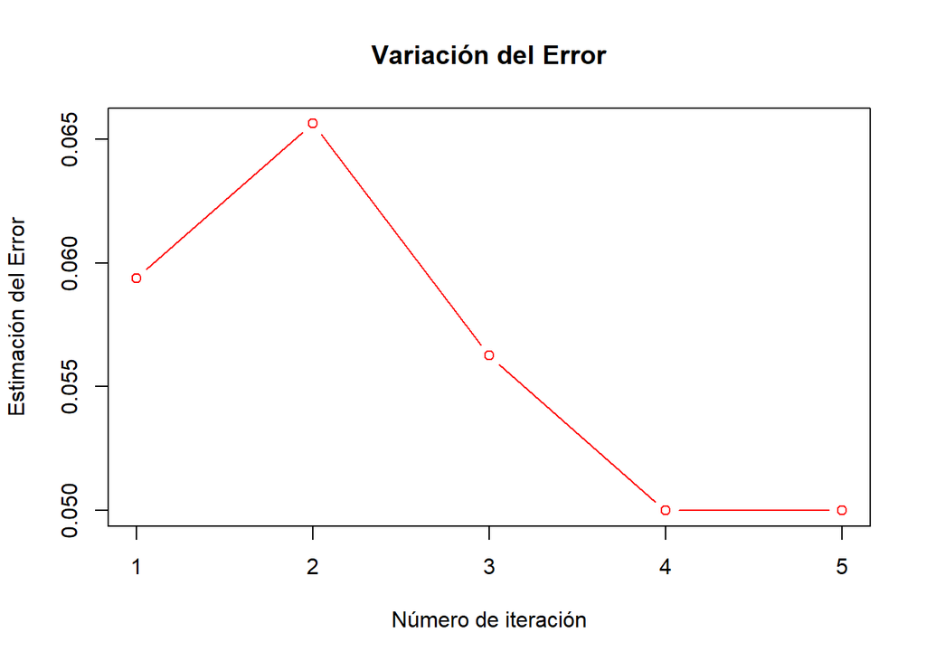

```r
## Ejercicio 1.2

v.error.tt<-rep(0,5)

for(i in 1:5) {
  muestra <- createDataPartition(Datos$tipo, times=1, p=0.25, list=FALSE)
  ttesting <- Datos[muestra, ]
  ttraining <- Datos[-muestra, ]

  modelo <- train.knn(tipo~.,data=ttraining,kmax=50)

  prediccion <- predict(modelo,ttesting,type = "class")

  MC <- confusion.matrix(ttesting, prediccion)

  acierto<-sum(diag(MC))/sum(MC)
  error <- 1- acierto
  v.error.tt[i] <- error
}
plot(v.error.tt,col="red",type="b",main="Variación del Error",xlab="Número de iteración",ylab="Estimación del Error")
```

## 1.3

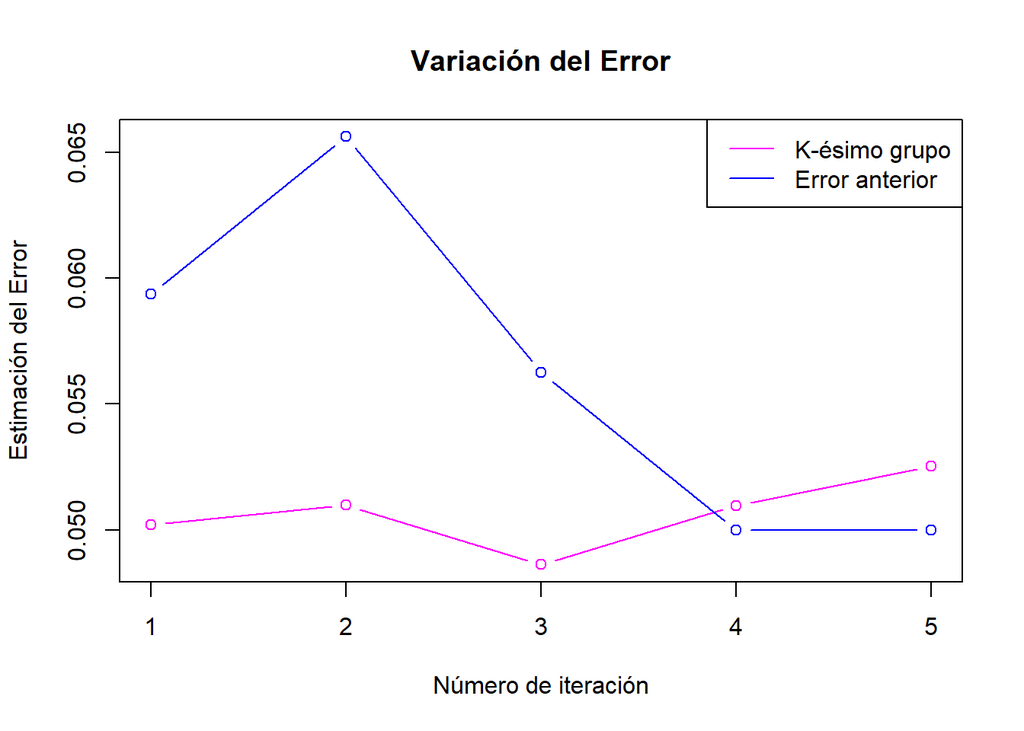

```r
## Ejercicio 1.3

n <- dim(Datos)[1] # Aquí n=150
## Vamos a generar el modelo dejando un grupo para testing y los demás datos para aprendizaje.
v.error.kg<-rep(0,5)
# Hacemos validación cruzada 10 veces para ver que el error se estabiliza
for(i in 1:5) {
  errori <- 0
  # Esta instrucción genera los k=5 grupos (Folds)
  grupos <- createFolds(1:n,10) # grupos$Fold0i es el i-ésimo grupo
  # Este ciclo es el que hace "cross-validation" (validación cruzada) con 5 grupos (Folds)
  for(k in 1:10) {
      muestra <- grupos[[k]] # Por ser una lista requiere de doble paréntesis
      ttesting <- Datos[muestra,]
      ttraining <- Datos[-muestra,]
      modelo <- train.knn(tipo~.,data=ttraining,kmax=50)
      prediccion <- predict(modelo,ttesting,type = "class")
      MC <- confusion.matrix(ttesting, prediccion)
      # Porcentaje de buena clasificación y de error
      acierto<-sum(diag(MC))/sum(MC)
      error <- 1 - acierto
      errori <- errori + error
  }
  v.error.kg[i] <- errori/10
}
plot(v.error.kg, col = "magenta", type = "b", ylim = c(min(v.error.kg, v.error.tt), max(v.error.kg,
    v.error.tt)), main = "Variación del Error", xlab = "Número de iteración",
    ylab = "Estimación del Error")
points(v.error.tt, col = "blue", type = "b")
legend("topright", legend = c("K-ésimo grupo","Error anterior"), col = c("magenta",
    "blue","red","green"), lty = 1, lwd = 1)
```

## 1.4

Gracias al grafico, se puede concluir que el error de knn con k-fold-cross-validation es mucho mas estable y menor. Lo que deja como conclusion que que es mucho mejor utilizar el metodo de fold-cross-validation, es decir, en grupos, donde se pueda utilizar y probar toda la tabla, para asi poder obtener un error mas preciso

# EJERCICIO 2

## 2.1

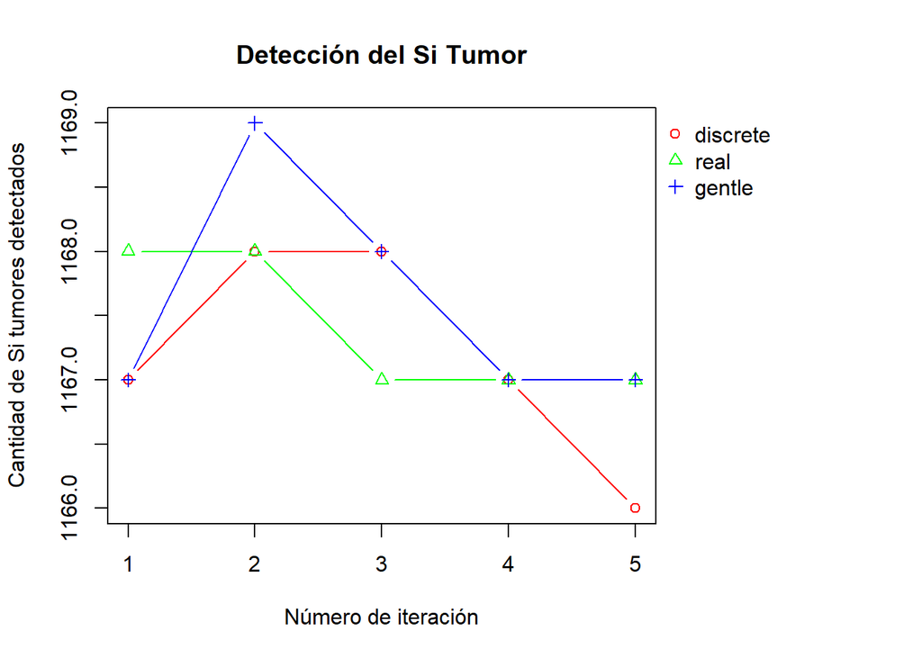

```r
numero.filas <- nrow(Datos)
cantidad.validacion.cruzada <- 5
cantidad.grupos <- 10
tam <- floor(sqrt(nrow(Datos)))

#si's
deteccion.si.discrete <- c()
deteccion.si.real <- c()
deteccion.si.gentle <- c()

#errores
deteccion.error.discrete <- c()
deteccion.error.real <- c()
deteccion.error.gentle <- c()




for(i in 1:cantidad.validacion.cruzada){
  grupos  <- createFolds(1:numero.filas, cantidad.grupos)  # Crea los 10 grupos
  si.discrete <- 0
  si.real <- 0
  si.gentle <- 0

  error.discrete <- 0
  error.real <- 0
  error.gentle <- 0

  # Este ciclo es el que hace 'cross-validation' (validación cruzada) con 10
  # grupos (Folds)
  for(k in 1:cantidad.grupos) {
    muestra <- grupos[[k]]  # Por ser una lista requiere de doble paréntesis
    ttesting <- Datos[muestra, ]
    ttraining <- Datos[-muestra, ]

    #discrete
    modelo<-train.ada(tipo~.,data=ttraining,iter=80,nu=1,type="discrete")
    prediccion <- predict(modelo, ttesting)
    MC <- confusion.matrix(ttesting, prediccion)
    si.discrete <- si.discrete + MC[2,2] # Detección de 1's
    # Cálculo del ERROR
    error.discrete<-error.discrete+(1-(sum(diag(MC)))/sum(MC))*100


     #real
    modelo<-train.ada(tipo~.,data=ttraining,iter=80,nu=1,type="real")
    prediccion <- predict(modelo, ttesting)
    MC <- confusion.matrix(ttesting, prediccion)
    si.real <- si.real + MC[2,2] # Detección de 1's
    # Cálculo del ERROR
    error.real<-error.real+(1-(sum(diag(MC)))/sum(MC))*100

     #gentle
    modelo<-train.ada(tipo~.,data=ttraining,iter=80,nu=1,type="gentle")
    prediccion <- predict(modelo, ttesting)
    MC <- confusion.matrix(ttesting, prediccion)
    si.gentle <- si.gentle + MC[2,2] # Detección de 1's
    # Cálculo del ERROR
    error.gentle<-error.gentle+(1-(sum(diag(MC)))/sum(MC))*100

  }

  deteccion.si.discrete[i] <- si.discrete
  deteccion.si.real[i] <- si.real
  deteccion.si.gentle[i] <- si.gentle

  #errores

  deteccion.error.discrete[i] <- error.discrete/cantidad.grupos
  deteccion.error.real[i] <- error.real/cantidad.grupos
  deteccion.error.gentle[i] <- error.gentle/cantidad.grupos

}

#===============
resultados <- data.frame("discrete" = deteccion.si.discrete,
                         "real" = deteccion.si.real,
                         "gentle" = deteccion.si.gentle)

par(oma=c(0, 0, 0, 8)) # Hace espacio para la leyenda

matplot(resultados, type="b", lty = 1, lwd = 1, pch = 1:ncol(resultados),
        main = "Detección del Si Tumor",
        xlab = "Número de iteración",
        ylab = "Cantidad de Si tumores detectados",
        col = rainbow(ncol(resultados)))
legend(par('usr')[2], par('usr')[4], legend = colnames(resultados),bty='n', xpd=NA,
       pch=1:ncol(resultados), col = rainbow(ncol(resultados))) # La leyenda
```

##### Para este caso, el mejor metodo ha sido ‘gentle’, sin embargo no es muy claro determinar cual de todos fue el mejor, ya que en algunos existe una alta precision con los 1’s pero existe tambien un error global alto, por lo tanto, cuesta un poco determinar cual ha sido el mejor

## 2.2

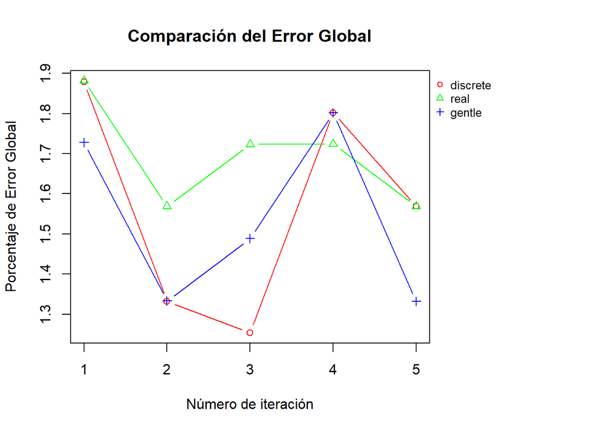

```r
# Errores

resultados <- data.frame("discrete" = deteccion.error.discrete,
                         "real" = deteccion.error.real,
                         "gentle" = deteccion.error.gentle)

par(oma=c(0, 0, 0, 8)) # Hace espacio para la leyenda
matplot(resultados, type="b", lty = 1, lwd = 1, pch = 1:ncol(resultados),
        main = "Comparación del Error Global",
        xlab = "Número de iteración",
        ylab = "Porcentaje de Error Global",
        col = rainbow(ncol(resultados)))
legend(par('usr')[2], par('usr')[4], legend = colnames(resultados),bty='n', xpd=NA, cex = 0.8,
       pch=1:ncol(resultados), col = rainbow(ncol(resultados))) # La leyenda
```

##### El mejor algoritmo a la hora de correr el ejercicio ha sido ‘gentle’, ya que para este metodo se obtiene una mayor acrtacion en los 1’s, ademas de que el error global se mantiene bastante bajo, lo que significa que ha sido bastante preciso. Claramente el reultado puede cambiar a la hora de ejecutar el archivo nuevamente.

## 2.3

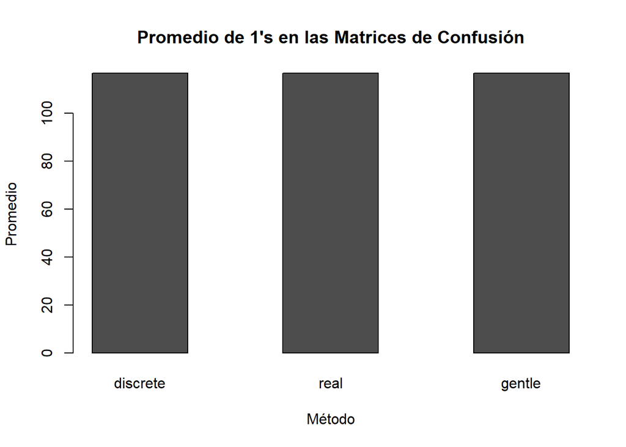

```r
 # Lista para almacenar las matrices de confusión por iteración
lista.matrices.discrete <- list()
lista.matrices.real <- list()
lista.matrices.gentle <- list()



for (i in 1:cantidad.validacion.cruzada) {
  grupos <- createFolds(1:numero.filas, cantidad.grupos)
  # Lista para almacenar las matrices de confusión por cada k
  matrices.discrete <- list()
  matrices.real <- list()
  matrices.gentle <- list()

  for (k in 1:cantidad.grupos) {
    muestra <- grupos[[k]]
    ttesting <- Datos[muestra, ]
    ttraining <- Datos[-muestra, ]

    # discrete
    modelo<-train.ada(tipo~.,data=ttraining,iter=80,nu=1,type="discrete")
    prediccion <- predict(modelo, ttesting)
    MC <- confusion.matrix(ttesting, prediccion)
    matrices.discrete[[k]] <- MC

    # real
    modelo<-train.ada(tipo~.,data=ttraining,iter=80,nu=1,type="real")
    prediccion <- predict(modelo, ttesting)
    MC <- confusion.matrix(ttesting, prediccion)
    matrices.real[[k]] <- MC

    #gentle
    modelo<-train.ada(tipo~.,data=ttraining,iter=80,nu=1,type="gentle")
    prediccion <- predict(modelo, ttesting)
    MC <- confusion.matrix(ttesting, prediccion)
    matrices.gentle[[k]] <-MC

  }

   #inserta el promedio de las matrices del for interno en otra lista
  lista.matrices.discrete[[i]] <- Reduce('+', matrices.discrete) / length(matrices.discrete)
  lista.matrices.real[[i]] <-  Reduce('+', matrices.real) / length(matrices.real)
  lista.matrices.gentle[[i]] <- Reduce('+', matrices.gentle) / length(matrices.gentle)

}


#saca el promedio de la lista de matrices de confusion promedio
matriz.promedio.discrete <- Reduce('+', lista.matrices.discrete) / length(lista.matrices.discrete)
matriz.promedio.real <- Reduce('+', lista.matrices.real) / length(lista.matrices.real)
matriz.promedio.gentle <-Reduce('+', lista.matrices.gentle) / length(lista.matrices.gentle)


# Medicion de 1's
resultados <- data.frame("discrete" = matriz.promedio.discrete[2,2],
                         "real" = matriz.promedio.real[2,2],
                         "gentle" = matriz.promedio.gentle[2,2])


# Obtener los nombres de las columnas
nombres_columnas <- colnames(resultados)

# Crear el gráfico de barras
barplot(as.matrix(resultados), beside = TRUE, legend.text = TRUE,
        main = "Promedio de 1's en las Matrices de Confusión", xlab = "Método",
        ylab = "Promedio", names.arg = nombres_columnas)
```

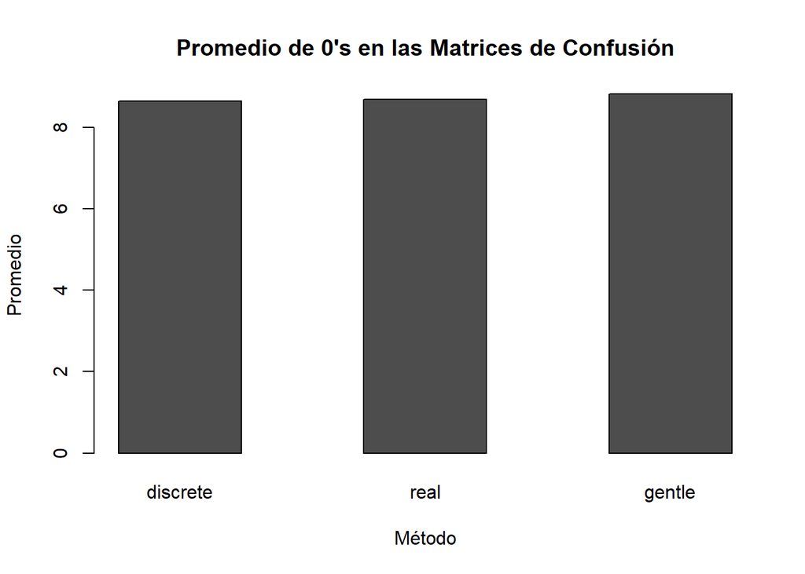

```r
# Medicion de 0's
resultados <- data.frame("discrete" = matriz.promedio.discrete[1,1],
                         "real" = matriz.promedio.real[1,1],
                         "gentle" = matriz.promedio.gentle[1,1])


# Obtener los nombres de las columnas
nombres_columnas <- colnames(resultados)

# Crear el gráfico de barras
barplot(as.matrix(resultados), beside = TRUE, legend.text = TRUE,
        main = "Promedio de 0's en las Matrices de Confusión", xlab = "Método",
        ylab = "Promedio", names.arg = nombres_columnas)
```

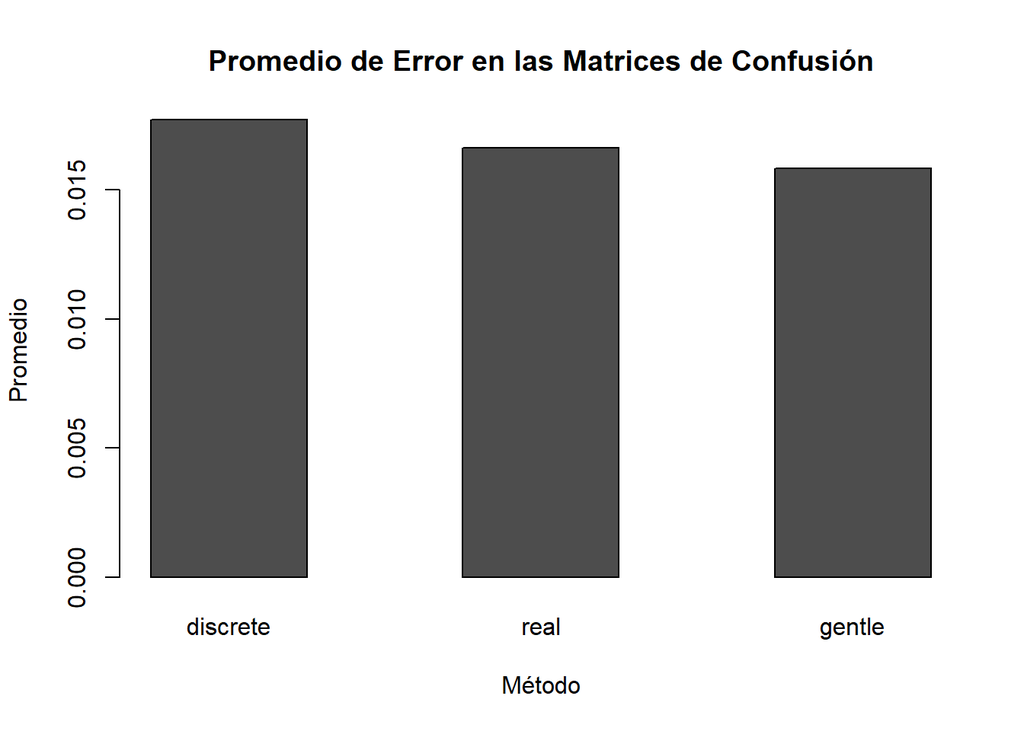

```r
# Medicion de error


resultados <- data.frame("discrete" = general.indexes(mc=matriz.promedio.discrete)$overall.error,
                         "real" = general.indexes(mc=matriz.promedio.real)$overall.error,
                         "gentle" = general.indexes(mc=matriz.promedio.gentle)$overall.error)


# Obtener los nombres de las columnas
nombres_columnas <- colnames(resultados)

# Crear el gráfico de barras
barplot(as.matrix(resultados), beside = TRUE, legend.text = TRUE,
        main = "Promedio de Error en las Matrices de Confusión", xlab = "Método",
        ylab = "Promedio", names.arg = nombres_columnas)
```

### 2.4

##### Yo utilizaria el metodo ‘gentle’, debido a lo explicado en la conclusion del ejercicio 2.2 y a que podemos observar que es el que tiene mejores resultados a la hora de compilado.